# PREPROCESSING DATA FOR 2019 UK ELECTION

**SCRIPT DESCRIPTION:**  
This script is used to prepare the data for spatial analysis of the UK general election in 2019. The preprocessing includes several data wrangling steps that prepares the election, demographic, and spatial data for further analysis. The preprocessed data is saved as a shapefile to the data directory. Hence, this script contains the data manipulations needed to get the required dataframe for spatial analysis of spatial features of the general election in 2019 in the United Kingdom.

**The 2019 election results were retrieved from:**  
https://commonslibrary.parliament.uk/research-briefings/cbp-8647/

**The shapefile of the constituencies was retrieved from:**  
https://data.gov.uk/dataset/4fd0633a-1c26-4619-b905-15c89ff7c6a0/westminster-parliamentary-constituencies-december-2016-full-clipped-boundaries-in-great-britain

**The age and population data was retrieved from:**  
https://www.ons.gov.uk/peoplepopulationandcommunity/populationandmigration/populationestimates/datasets/parliamentaryconstituencymidyearpopulationestimates

**The data on ethnicity was retrieved from:**  
https://commonslibrary.parliament.uk/constituency-statistics-ethnicity/

**Pub data was derieved through:**  
https://www.kaggle.com/rtatman/every-pub-in-england?select=open_pubs.csv

**Postcode data was acquired from:**  
https://www.getthedata.com/open-postcode-geo

**Income data was derieved through:**  
https://www.gov.uk/government/statistics/income-and-tax-by-parliamentary-constituency-confidence-intervals

**And the urban and rural classification data was retrieved from:**  
https://www.ons.gov.uk/methodology/geography/geographicalproducts/ruralurbanclassifications/2001ruralurbanclassification/ruralurbanlocalauthoritylaclassificationengland

NB! Some of the files have been slightly modified to get to a computer readable csv format.

**Loading libraries:**

```r
# Install and load pacman for package management
#install.packages("pacman")
library(pacman)

# Install/load required libraries
p_load(tidyverse,
       sf,
       tmap,
       rgdal,
       spatialEco)
```

**Reading the data:**  
In this chunk we are simply loading the 2019 UK election data results, the spatial data of parliamentary constituencies, rural/urban classification data, as well as demographic data.

```r
# Load 2019 UK election data (predictor)
election_2019_uk <- read_csv("../data/2019election_results.csv")

# Load shapefile of English parliamentary constituencies data
constituencies <- st_read("../data/Westminster_Parliamentary_Constituencies_(December_2016)_Boundaries.shp")
# Population density and age data
age_and_population <- read_csv("../data/age_data.csv")

# Ethnicity data
ethnicity <- read_csv("../data/ethnicity_data.csv")

# Income data
income <- read_csv("../data/income_data.csv")

# Urban and rural data
pop_rural_urban <- read_csv("../data/Population_and_rural_urban.csv")

# Pub data
pubs <- read_csv("../data/open_pubs.csv")

# Postcode geodata
postcodes <- read.csv("../data/open_postcode_geo.csv", stringsAsFactors=FALSE)
```

**Data wrangling for the election data:**  
- Filter election results to only keep data from English constituencies  
- Calculate percentage votes for the Conservative Party and the Labour Party  
- Subset data relevant for the spatial analysis  
- Check distribution of votes for the Conservative Party and the Labour Party

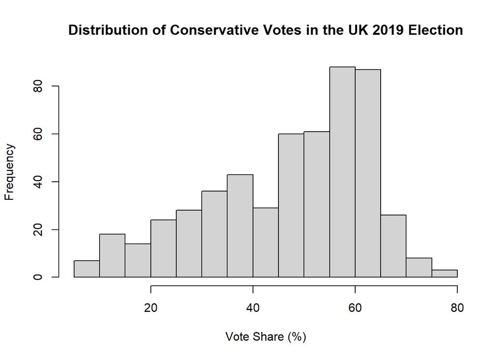

```r
# Filter election data by England
election_2019_eng <- election_2019_uk %>%
  filter(Country == "England")

# Calculate percentage votes for conservative and labour
election_2019_eng <- election_2019_eng %>%
  mutate(perc_votes_conservative = ConservativeVotes/`Total votes`*100,
         perc_votes_labour = LabourVotes/`Total votes`*100) %>%
  mutate(Electorate = as.numeric(Electorate))

# Keep only relevant columns
election_subset <- election_2019_eng %>%
  dplyr::select(Constituency, perc_votes_conservative, perc_votes_labour, Electorate, County)

# Check distribution of votes for conservatives
hist(election_subset$perc_votes_conservative,
     main = "Distribution of Conservative Votes in the UK 2019 Election",
     xlab = "Vote Share (%)")
```

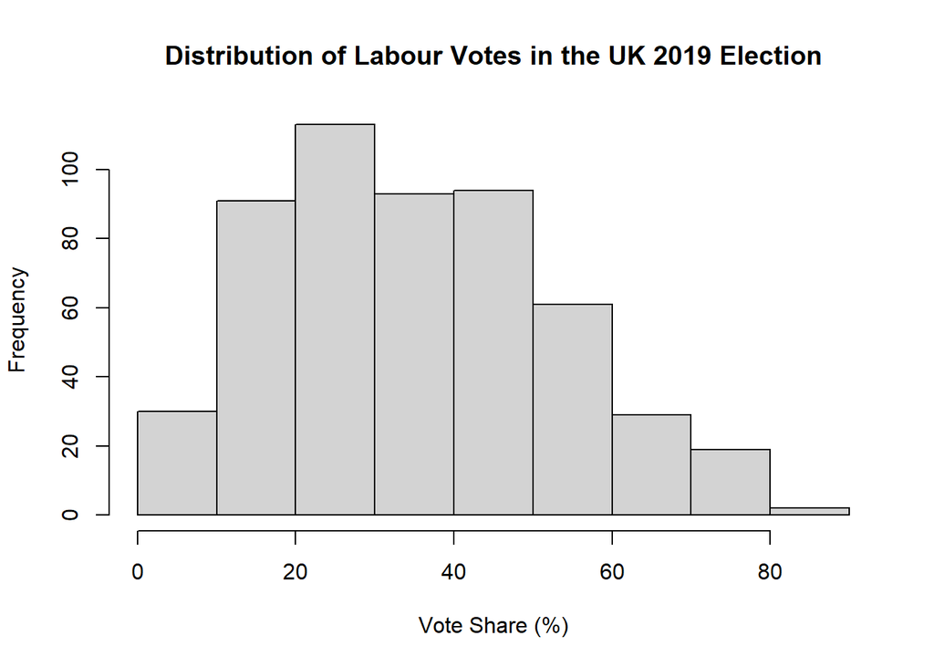

```r
# Check distribution of votes for labour
hist(election_subset$perc_votes_labour,
     main = "Distribution of Labour Votes in the UK 2019 Election",
     xlab = "Vote Share (%)")
```

From the two histograms, we can see that the votes for the conservatives are a little skewed towards higher percentages whereas the votes for labour are more skew towards lower percentages. To correct this, a log transformation might be considered. However, both distributions have a large range of percentages and from this we can gather that there is a great variation in voting patterns across constituencies.  
So, now we have election data that is ready to be merged.

**Data wrangling for the age and population data:**  
The data is structured with a column for each age (0-90+) and a row for each constituency.  
- Calculate average age across all age columns  
- Rename population column  
- Subset data relevant for the spatial analysis  
- Check distribution of population and average age across constituencies

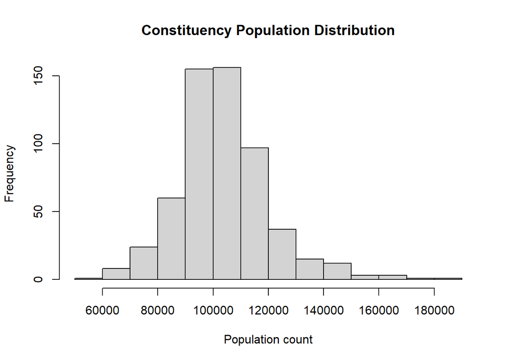

```r
# Set counter to zero
counter = 0

# Create column for average age
age_and_population$average_age <- 0

# For each constituency in the data
for (constituency in 1:nrow(age_and_population)){

  # For age column in the range of ages
  for (i in (0:90)){

    # Age is the current iteration
    age = i

    # Get population with that age in the current constituency
    pop = age_and_population[[constituency, (i + 4)]] # i + 4 since column number will increase

    # Product of age and number of population with that age
    total = age*pop

    # Add product to counter
    counter = counter + total # this will give the sum of the population * age for all ages
  }

  # Calculate average age by dividing the sum with total population
  average = counter/age_and_population[[constituency, 3]] # column 3 = All ages

  # Add average age for constituency to the new column
  age_and_population[constituency, 95] <- average

  # Set counter to zero before starting over with new constituency
  counter = 0
}

# Take relevant columns
age_and_population_subset <- age_and_population %>%
  # Change name of population column
  mutate(population = `All Ages`) %>%
  # Change names of constituencies to uppercase to match election data
  mutate(PCON11NM = toupper(PCON11NM)) %>%
  # Keep only relevant columns
  dplyr::select(PCON11NM, population, average_age)

# Check distribution of population
hist(age_and_population_subset$population,
     main = "Constituency Population Distribution",
     xlab = "Population count")
```

```r
# Check population range
range(age_and_population_subset$population)
```

```
## [1]  59177 188634
```

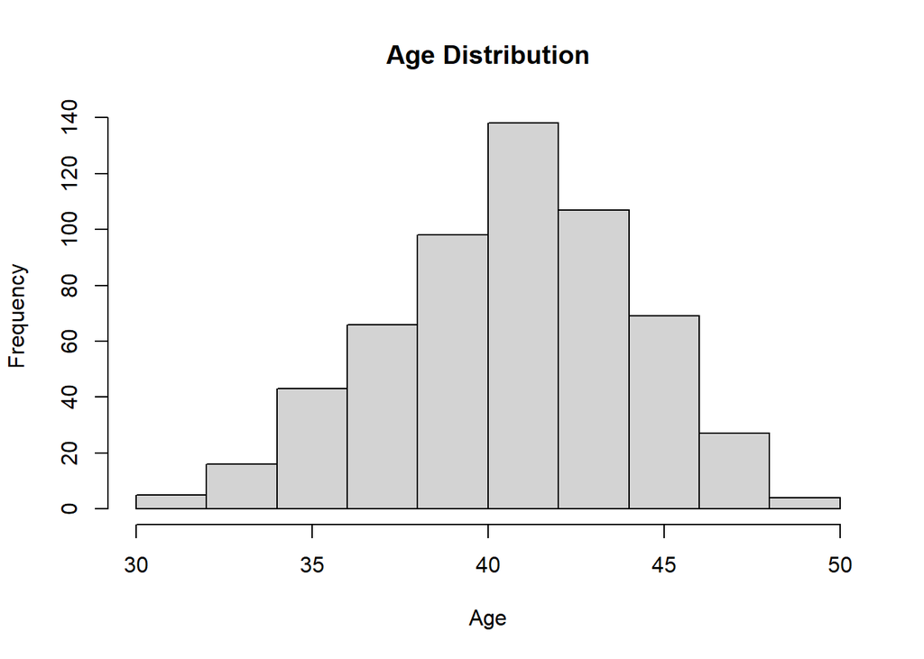

```r
# Check distribution of average age
hist(age_and_population_subset$average_age,
     main = "Age Distribution",
     xlab = "Age")
```

```r
# Check age range
range(age_and_population_subset$average_age)
```

```
## [1] 30.77135 49.68499
```

Both variables appear to be approximately normally distributed. Populations vary from around 60000 to around 190000. Similarly, mean age range from around 31 to around 50 years.  
From this, we have acquired population and average age ready for merging.  
**Data wrangling for the income data:**  
The income data is already fit for analysis  
- Rename mean income column  
- Subset data relevant for the spatial analysis  
- Check distribution of average income

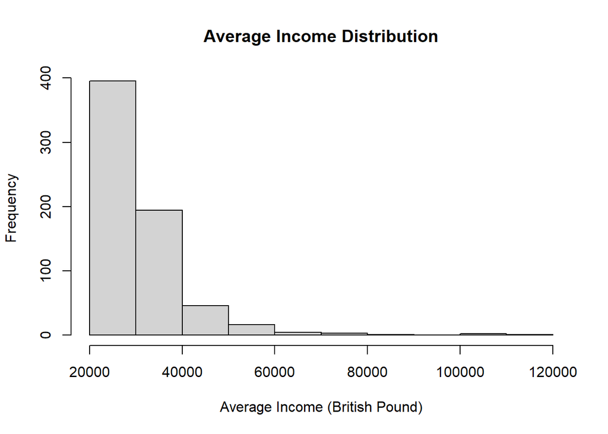

```r
# Subset income data
income_subset <- income %>%
  # Remove NA's from empty rows
  filter(!is.na(X1)) %>%
  # Change column name for mean income
  mutate(mean_income = `Central Estimate (mean)`) %>%
  # Change names of constituencies to uppercase to match election data
  mutate(X2 = toupper(X2)) %>%
  # Select relevant columns for subsetting
  dplyr::select(X2, mean_income)

# Check distribution of average income
hist(income_subset$mean_income,
     main = "Average Income Distribution",
     xlab = "Average Income (British Pound)")
```

```r
# Check income range
range(income_subset$mean_income)
```

```
## [1]  22400 119000
```

The data for average income is very skewed with most values around 20000 and few values over 60000. However, the range is quite large (22400 - 119000 British Pounds).

**Data wrangling for ethnicity data:**  
As a proxy for ethnic diversity (or more specifically lack of diversity), we extract values from column of how many percent white make of the population in each constituency.  
- Get percentage white population  
- Subset data relevant for the spatial analysis  
- Check distribution of the percentage of white population across constituencies

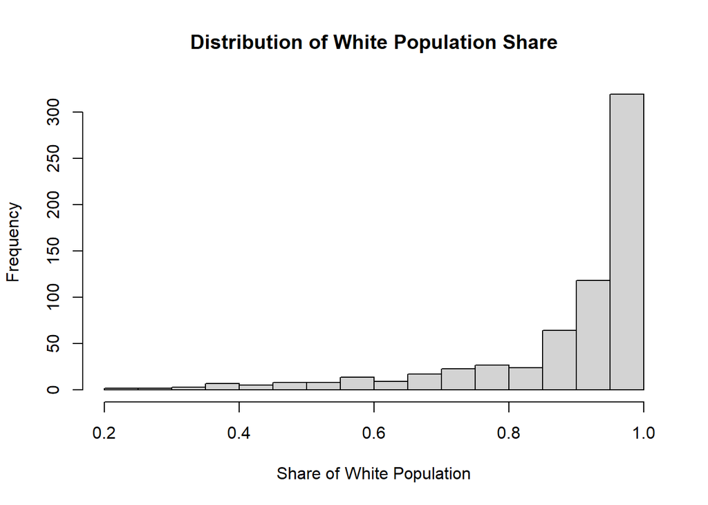

```r
# Ethnicity data
ethnicity_subset <- ethnicity %>%
  # Rename column for percentage of white population
  mutate(percentage_white_pop = `PopWhiteConst%`) %>%
  # Change names of constituencies to uppercase to match election data
  mutate(ConstituencyName = toupper(ConstituencyName)) %>%
  # select relevant columns for subsetting
  dplyr::select(percentage_white_pop, ConstituencyName)

# Check distribution of ethnic diversity
hist(ethnicity_subset$percentage_white_pop,
     main = "Distribution of White Population Share",
     xlab = "Share of White Population")
```

From the histogram of how many percent whites make out of the total population in each constituency, it is quite clear that for most constituencies white people make up the large majority of the population (~90-100%).  
However, some constituencies like East Ham have more diverse populations where white people only comprise around 1/4 of the total population.  
**Data wrangling for urban and rural data:**  
- Change classification to binary class  
- Count number of rural and urban constituencies  
- Select and subset relevant variables

```r
# Using string replace to redefine urban and rural as binary class
pop_rural_urban$Classification <- pop_rural_urban$Classification %>%
  str_replace(pattern = ".*_urban$", replacement = "urban") %>%
  str_replace(pattern = ".*ural.*", replacement = "rural")

# Count number of rural and urban constituencies
pop_rural_urban %>%
  group_by(Classification) %>%
  summarise(count = n())
```

```
## # A tibble: 2 x 2
##   Classification count
##   <chr>          <int>
## 1 rural            179
## 2 urban            354
```

```r
# Rural constituencies = 179
# Urban constituencies = 354

# Subset data
rural_urban_subset <- pop_rural_urban %>%
  # Rename column for constituencies and change names to upper
  mutate(Constituency = toupper(Constituency_2)) %>%
  # Select relevant columns for subsetting
  dplyr::select(Constituency, Classification)
```

So, from this we see that there are approximately twice as many urban constituencies compared to rural constituencies.  
**Merge data:**  
Before preparing the pub data, we merge all data we have prepared so far and add it to the spatial polygon data.

```r
# Merge election data and age and population data by constituency
all_data <- merge(election_subset, age_and_population_subset, by.x = "Constituency", by.y = "PCON11NM")

# Merge with income data
all_data <- merge(all_data, income_subset, by.x = "Constituency", by.y = "X2")

# Merge with ethnicity data
all_data <- merge(all_data, ethnicity_subset, by.x = "Constituency", by.y = "ConstituencyName")

# Merge with rural urban data
all_data <- merge(all_data, rural_urban_subset, by = "Constituency")

# Make constituency names upper case to match
constituencies$pcon16nm <- toupper(constituencies$pcon16nm)

# Merge attribute data with spatial constituency data
constituency_data <- merge(constituencies,
                           all_data,
                           by.x = "pcon16nm",
                           by.y = "Constituency")
```

**Pubs per inhabitant**  
We are missing longitude and latitude for 72 pubs. To restore these, we first try to use easting and northing coordinates. However, they seem to be corrupted and therefore, we instead opt to merge the data with longitude and latitude data for postcodes in the UK. While inspecting the data, we noticed that postcode was misplaced twice in address column.  
- Create two datasets - one for rows without longitude and one for rows with longitude data.  
- Try to recover the missing longitude and latitude from easting and northing.  
- Add the misplaced postcodes to the postcode column.  
- Merge pub data with missing coordinates and postcode data.  
- Rowbind pub data with recovered coordinates to the rest of the pub data.  
- Transform pub dataframe to sf object and assign crs.

```r
#--------Creating two datasets----------
# Convert to numeric
pubs$latitude <- as.numeric(pubs$latitude)
pubs$longitude <- as.numeric(pubs$longitude)
# Check missing latitude
plyr::count(is.na(pubs$latitude))
```

```
##       x  freq
## 1 FALSE 51496
## 2  TRUE    70
```

```r
# Check missing longitude
plyr::count(is.na(pubs$longitude))
```

```
##       x  freq
## 1 FALSE 51494
## 2  TRUE    72
```

```r
# Save pub data without longitude NA's
pubs_no_NAs <- pubs %>%
  filter(!is.na(longitude))

# Save pub data with longitude NA's
pubs_NAs <- pubs %>%
  filter(is.na(pubs$longitude))

#---------Trying to get missing long and lat from easting and northing----------

# Function to find UTM from longitude
long2UTM <- function(long) {
    (floor((long + 180)/6) %% 60) + 1
}
# Find min and max UTM from min and max longitude
minLong <- min(pubs_no_NAs$longitude); minUTM <- long2UTM(minLong) # UTM: 29
maxLong <- max(pubs_no_NAs$longitude); maxUTM <- long2UTM(maxLong) # UTM: 31

# print min and max UTM
printf <- function(...) cat(sprintf(...))
printf("Min UTM: %d, Max UTM: %d", minUTM, maxUTM)
```

```
## Min UTM: 29, Max UTM: 31
```

```r
# transform easting and northing to longitude and latitude from utm
longlat_df <- pubs_NAs %>%
  st_as_sf(coords = c("easting", "northing"), crs = CRS("+proj=utm +zone=30")) %>%
  st_transform(crs = 27700) %>%
  st_coordinates() %>%
  as.data.frame()

# save coordinates as latitude and longitude
pubs_NAs$latitude <- longlat_df$Y
pubs_NAs$longitude <- longlat_df$X

# Transform to sf object
pubs_NAs_filtered_sf <- st_as_sf(pubs_NAs,
                                coords = c("longitude", "latitude"))

# Setting CRS
pubs_NAs_filtered_sf <- st_set_crs(pubs_NAs_filtered_sf, 27700)
# plotting geometry
plot(pubs_NAs_filtered_sf$geometry)
```

[output not shown]

```r
#DIDN'T WORK - MUST HAVE CORRUPTED EASTING AND NORTHING

#-----------Merging pub data with postcode data---------

# adding misplaced postcode in postcode column
for (row in 1:nrow(pubs_NAs)){
  if (pubs_NAs[row,"address"] == "YO17 7LX"){
    pubs_NAs[row, "postcode"] = "YO17 7LX"
  }
  if (pubs_NAs[row,"address"] == "EN11 8TN"){
    pubs_NAs[row, "postcode"] = "EN11 8TN"
  }
}

# drop latitude and longitude column
pubs_NAs <- pubs_NAs[,-c(7:8)]

# subsetting the postcode data to keep only relevant columns
pc <- cbind(postcodes[,c(1,8,9)])
# renaming columns to match pubs data
colnames(pc)<- c("postcode","latitude","longitude")

# merging postcode data with the NA pubs data
pubs_pc <- merge(x=pubs_NAs, y=pc, by="postcode")

# checking which pubs are removed
for (name in pubs_NAs$name){
  if (name %in% pubs_pc$name){
    # do nothing
  }
  else {
    print(paste(name, "is not in the data!"))
  }
}
```

```
## [1] "Worthing United Football Club is not in the data!"
## [1] "Dearne Valley Farm is not in the data!"
```

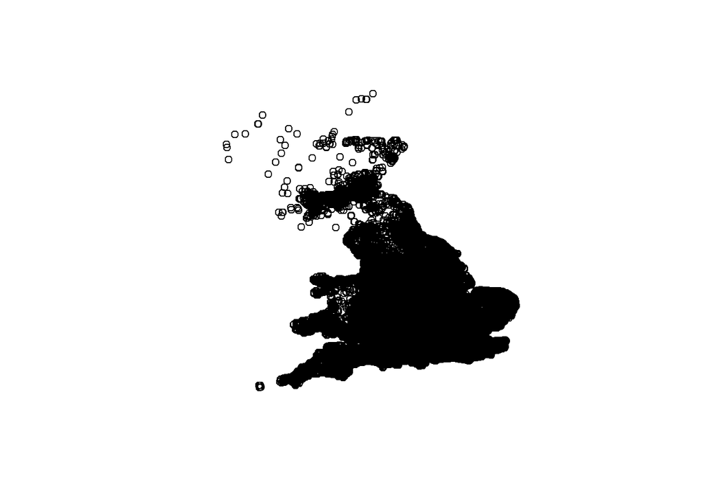

```r
# merging the pub data to get full data set
pubs_merged <-  rbind(pubs_no_NAs, pubs_pc)

# Transform to sf object
pubs_merged_sf <- st_as_sf(pubs_merged, coords = c("longitude", "latitude"))

# Plot pub geometry
plot(pubs_merged_sf$geometry)
```

```r
# Transform CRS
pubs_merged_sf <- st_set_crs(pubs_merged_sf, 4326)
pubs_merged_sf <- st_transform(pubs_merged_sf, crs = 27700)
```

This gives us 51564 pubs out of 51566. The missing two pubs are Worthing United Football Club and Dearne Valley Farm as their postcodes are not the the postcode geo data.  
Now that we have the coordinates for the pubs we need to calculate pubs per inhabitant. For this calculation, we first have to calculate how many pubs are in each constituency.  
We start by merging the pub data with the constituencies data to remove data from Wales and Scotland.

```r
# transform crs for constituency data
constituency_data <- st_transform(constituency_data, crs = 27700)

# There are missing voting values for Chorley so we remove them before calculating neighbors
constituency_data <- constituency_data %>%
  filter(pcon16nm != "CHORLEY")

# Check if the CRS of the constituencies and the pubs match
st_crs(pubs_merged_sf)==st_crs(constituency_data)
```

```
## [1] TRUE
```

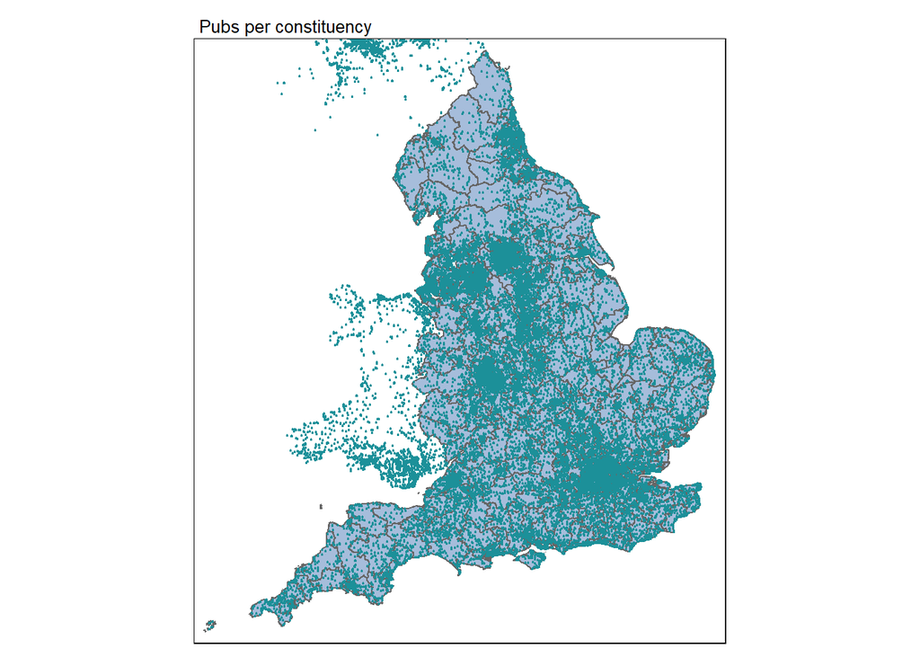

```r
# Plot with tmap
tm_shape(constituency_data)  +
  tm_polygons(col = "#a6bddb") + # colors are found on colorbrewer2.org
  tm_shape(pubs_merged_sf$geometry) +
  tm_layout(main.title = "Pubs per constituency", main.title.size = 0.8) +
  tm_dots(col = "#1c9099", # added color from colorbrewer2.org
             size = 0.01)
```

```r
# Filter out Scotland and Wales using st_intersection()
pubs_england <- st_intersection(pubs_merged_sf, constituency_data)
```

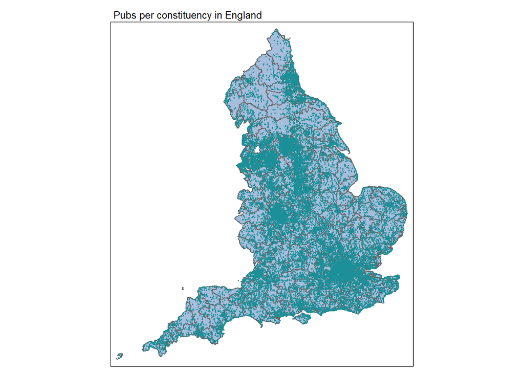

```r
# Plot geometry for intersection to see if it only includes England
tm_shape(constituency_data)  +
  tm_polygons(col = "#a6bddb") + # colors are found on colorbrewer2.org
  tm_shape(pubs_england$geometry) +
  tm_layout(main.title = "Pubs per constituency in England", main.title.size = 0.8) +
  tm_dots(col = "#1c9099", # added color from colorbrewer2.org
             size = 0.01)
```

Finally, we can count pubs in each constituency. For this we use a function from the spatialEco package. This function intersects point and polygon feature classes and adds polygon attributes to points.

```r
# Using point in poly function to get pubs for each constituency
pts.poly <- point.in.poly(pubs_england, constituency_data)
# Inspecting the data
head(pts.poly@data)
```

```
##   fas_id                                     name
## 1 247785 Blackwater And Hawley Leisure Centre Bar
## 2 248016                             Jackson Club
## 3 248242                             The Bell Inn
## 4 248256                    The Crown And Cushion
## 5 248294                           The Royal Swan
## 6 268311                   Aldershot & Fleet RUFC
##                                                                          address
## 1                                    Hawley Green, Blackwater, Camberley, Surrey
## 2                         Gibraltar Barracks, Minley Road, Blackwater, Camberley
## 3                                36 Frogmore Road, Blackwater, Camberley, Surrey
## 4                          Crown And Cushion, Minley Road, Blackwater, Camberley
## 5                       The Royal Swan Hotel, London Road, Blackwater, Camberley
## 6 Aldershot And Fleet Rugby Club Pavi, Aldershot Park, Guildford Road, Aldershot
##   postcode easting northing local_authority pcon16nm.x objectid.x pcon16cd.x
```

[output cut: 55 more lines]

```r
# Saving count of pubs in each constituency
pubs_counts <- pts.poly@data %>%
  group_by(pcon16nm.x) %>%
  summarize(pub_count=n())

# Merge constituency and pub data
constituency_data <- merge(constituency_data,
                           pubs_counts,
                           by.x = "pcon16nm",
                           by.y = "pcon16nm.x")

# Calculate pubs per inhabitant from pub count and population
constituency_data <- constituency_data %>%
  mutate(pubs_per_inhabitant = pub_count/population)
```

**Calculate population density:**  
Lastly, we calculate population density by first calculating the area for each polygon and then divide population by area.

```r
# Make new area column
constituency_data$area <- st_area(constituency_data)

# Population density
constituency_data <- constituency_data %>%
  mutate(pop_density = population/area)
```

**Save data:**  
Finally, we make last adjustments and save the data as a shapefile.

```r
# rename constituency column and drop unnecessary columns
constituency_data <- constituency_data %>%
  mutate(Constituency = pcon16nm) %>%
  subset(select = -c(1, 3:5,8:9))


# Save to data folder
st_write(constituency_data, "../data/space_data.shp", append = F)
```

```
## Deleting layer `space_data' using driver `ESRI Shapefile'
## Writing layer `space_data' to data source `../data/space_data.shp' using driver `ESRI Shapefile'
## Writing 531 features with 17 fields and geometry type Multi Polygon.
```